# R Primer

##### Multilevel Modeling – Summer 2019 – Sascha Göbel and Susumu Shikano

**Content**

1. Obtain and install R and RStudio
2. Getting to know RStudio
3. Learning the building blocks of the R language
4. Packages
5. Working with data
6. Further topics and ressources

## 1. Obtain and install R and RStudio

##### R

R is an open source (interpreted) programming language for statistical computing and graphics

- ranks among 10 most popular languages
- under continuous development
- thousands of user-created packages, which allow for canned specialized techniques
- large and active online community that has virtually every problem solved for you

##### Install R

To install R

- visit https://cran.r-project.org/ in your browser
- select the link that matches your operating system
- follow installation instructions, go for R version 3.6.0

##### RStudio

RStudio is an open source integrated development environment (IDE) which includes

- a text editor to write programs
- a console where programs are executed
- two multipurpose viewers showing graphs, the global environment section, etc.

##### Install RStudio

To install RStudio

- visit https://www.rstudio.com/products/rstudio/download/#download
- under “Installers” select the link that matches your operating system
- follow installation instructions

## 2. Getting to know R Studio

##### Basic setup

Within RStudio

- from the menu on top select ‘Tools’ > ‘Global Options’
- on the left panel, select ‘Code’
- under ‘Editing’ make sure ‘Ctrl+Enter executes’ defaults to ‘Current line’
- under ‘Saving’ make sure that ‘Default text encoding’ shows ‘UTF-8’
- on the left panel, select ‘Pane layout’
- make sure that the top left form shows ‘Source’ and the top right shows ‘Console’
- you can customize the bottom left and right forms as you like, I prefer to have the ‘Environment’, ‘History’, ‘Files’, ‘Plots’, ‘Packages’, and ‘Help’ in the lower right pane and the rest, which I rarely use, in the lower left
- click ‘Apply’ and then ‘OK’
- Otherwise, the defaults should be fine but you can further explore the global options to customize the ‘Appearance’ of RStudio, how RStudio highlights code snippets for you, autocompletes functions, and so on.

##### Source

The source pane is essentially a text editor where you document your R code

- on top is a project manager, which allows you to switch between R scripts
- `#` is used to place comments in code
- Note that R is case sensitive
- use CTRL+S to save your script
- use CTRL+ENTER to execute your script
- use CTRL+F to search and replace within your script
- More shortcuts? Try ALT+SHIFT+K

##### Console

The console pane is where your script is executed and output is shown

- R is ready when the console offers `>`
- a red stop sign indicates that R is computing, click it to cancel execution or hit ESC
- on top you see your current working directory, to change your working directory execute the following line of code with your directory typed inbetween quotes, note the use of forward slashes

```r
setwd("FILE/PATH/TO/YOUR/DIRECTORY")
```

- input is incomplete if R answers with `+` (likely forgotten a ‘)’ or ‘]’)
- recycle previous commands by using the arrow keys
- use CTRL+1 to switch to ‘Source’ and CTRL+2 to switch back to ‘Console’

##### The multipurpose panels

The multipurpose panels offer different functionalities depending on how you customized them

- the ‘Environment’ is a workspace viewer that lists objects (data, values, functions) you created and provides detailed information, it also allows to manually import data or a previously saved workspace
- the ‘History’ lists every single command executed in the current session
- ‘Plots’ displays graphs you generated
- ‘Packages’ shows installed packages with a brief description and allows you to manually load, detach, and install additional packages
- ‘Help’ provides detailed documentation of functions

## 3. Learning the building blocks of the R language

### Control abstraction, i.e., how to tell R what to do

##### Arithmetic operations

```r
5 + 3 # addition
```

```
#> [1] 8
```

```r
5 - 3 # subtraction
```

```
#> [1] 2
```

```r
5 ^ 3 # exponentiation
```

```
#> [1] 125
```

```r
5 ** 3 # exponentiation
```

```
#> [1] 125
```

```r
5 * 3 # multiplication
```

```
#> [1] 15
```

```r
5 / 3 # division
```

```
#> [1] 1.666667
```

```r
5 * (10 - 3) # use of brackets
```

```
#> [1] 35
```

```r
10 %% 3 # modulo, remainder of division
```

```
#> [1] 1
```

```r
10 %/% 3 # integer divide
```

```
#> [1] 3
```

##### Relational operations

```r
5 > 3 # greater than
```

```
#> [1] TRUE
```

```r
5 < 3 # less than
```

```
#> [1] FALSE
```

```r
5 <= 3 # weakly less than
```

```
#> [1] FALSE
```

```r
5 >= 3 # weakly greater than
```

```
#> [1] TRUE
```

```r
5 == 3 # equals
```

```
#> [1] FALSE
```

```r
5 != 3 # unequal
```

```
#> [1] TRUE
```

##### Assignment

R stores information as an object (in the environment) with a name of your choice. An object name cannot begin with a number, no spaces, avoid special characters that have special meaning in R, avoid function names. `<-` is the assignment operator, `=` works, too, but is considered bad practice.

```r
result <- 5 + 3 # assign
result # call object, note that calling 'Result' will throw an error as R is case sensitive
```

```
#> [1] 8
```

```r
result <- 5 ^ 3 # overwrite object
result
```

```
#> [1] 125
```

```r
results <- c(5 + 3, 5 - 3, result) # assigning multiple values using 'c()' - concatenate
results
```

```
#> [1]   8   2 125
```

##### Logical operations

```r
5 & 3 %in% results # logical conjunction (and)
```

```
#> [1] FALSE
```

```r
5 == 2 | 3 == 2 # logical disjunction (or)
```

```
#> [1] FALSE
```

```r
!3 %in% results # logical negation
```

```
#> [1] TRUE
```

##### Function calls

A function takes one or multiple inputs (called ‘arguments’) within brackets and produces an output. Good coding practice speels out the arguments. To learn about a function and its arguments type `?` in front of it and check the respective multipurpose panel for the function documentation.

```r
mean(x = results) # arithmetic mean
```

```
#> [1] 45
```

```r
base::mean(x = results) # to avoid conflict with other packages, specify the function source, i.e., the package, as 'source::', usually not necessary
```

```
#> [1] 45
```

```r
sqrt(x = result) # square root
```

```
#> [1] 11.18034
```

```r
sum(x = results) # sum of elements
```

```
#> [1] 135
```

```r
seq(from = 1, to = 10) # sequence
```

```
#>  [1]  1  2  3  4  5  6  7  8  9 10
```

```r
values <- seq(from = 1, to = 10, by = 2)
rep(x = result, times = 3) # replication of elements
```

```
#> [1] 125 125 125
```

```r
rep(x = results, each = 3)
```

```
#> [1]   8   8   8   2   2   2 125 125 125
```

```r
print(values) # print values
```

```
#> [1] 1 3 5 7 9
```

```r
print(c(values, result))
```

```
#> [1]   1   3   5   7   9 125
```

```r
cat(values, result)
```

```
#> 1 3 5 7 9 125
```

```r
print(mean(results)) # nested function calls
```

```
#> [1] 45
```

##### Subsetting operations

R provides three subsetting operators, `[`, `[[`, and `$` to extract or replace parts of an object. You will learn about these in detail below together with how to access different data structures. For now, just consider the `[` operator. Use `[]` to access, i.e., index, elements by position from the objects created thus far.

```r
results[3] # access the third element in results
```

```
#> [1] 125
```

```r
results # 125 is the third element in results
```

```
#> [1]   8   2 125
```

##### Control structures

Control structures allow you to control the flow of execution in a script, we distinguish conditional execution, loops, and conditional jumps. You can use all these structures to build your own functions, too (not covered here).

Conditional execution with `if` - `if (condition) {do}`

```r
if (result %in% results) {
  cat(result, "is in results")
}
```

```
#> 125 is in results
```

Conditional execution with `if` and `else` - `if (condition) {do} else {do}`

```r
if (sample(x = 1:20, size = 1) <= 10) {
  print("x is less than 10")
} else {
  print("x is greater than 10")
}
```

```
#> [1] "x is less than 10"
```

Conditional execution with vectorized `ifelse` - `ifelse(condition, if met do, else do)`

```r
values <- sample(x = 1:20)
ifelse(values >= 10, TRUE, FALSE)
```

```
#>  [1]  TRUE FALSE  TRUE FALSE  TRUE FALSE FALSE  TRUE  TRUE  TRUE  TRUE
#> [12]  TRUE FALSE  TRUE FALSE FALSE  TRUE  TRUE FALSE FALSE
```

`for` loop for iterative tasks - `for (element in sequence of elements) {do}`

```r
for (i in 1:length(values)) {
  print(values[i])
}
```

```
#> [1] 15
#> [1] 6
#> [1] 14
#> [1] 7
#> [1] 17
#> [1] 1
#> [1] 5
#> [1] 13
#> [1] 19
#> [1] 20
#> [1] 10
#> [1] 18
#> [1] 8
#> [1] 12
#> [1] 4
#> [1] 9
#> [1] 11
#> [1] 16
#> [1] 3
#> [1] 2
```

Note how ‘i’ appears in the global environment, this is a side effect of using control structures outside of functions - the state of the program is changed, i.e., the global environment is affected. Mind that this can have unanticipated consequences. `for` loop with conditional execution

```r
for (i in 1:length(values)) {
  if (values[i] >= 10) {
    print(TRUE)
  } else {
    print(FALSE)
  }
}
```

```
#> [1] TRUE
#> [1] FALSE
#> [1] TRUE
#> [1] FALSE
#> [1] TRUE
#> [1] FALSE
#> [1] FALSE
#> [1] TRUE
#> [1] TRUE
#> [1] TRUE
#> [1] TRUE
#> [1] TRUE
#> [1] FALSE
#> [1] TRUE
#> [1] FALSE
#> [1] FALSE
#> [1] TRUE
#> [1] TRUE
#> [1] FALSE
#> [1] FALSE
```

`while` loop - `while (condition is met) {do}`

```r
while (result < 200) {
  print(result)
  result <- result + 5
}
```

```
#> [1] 125
#> [1] 130
#> [1] 135
#> [1] 140
#> [1] 145
#> [1] 150
#> [1] 155
#> [1] 160
#> [1] 165
#> [1] 170
#> [1] 175
#> [1] 180
#> [1] 185
#> [1] 190
#> [1] 195
```

Again, note how the object “result” is altered in the global environment.

Conditional jump with `next` - skips processing element further and begins with next iteration, not required in this example but useful for nested loops or exception handling

```r
for(i in 1:length(values)) {
  if(values[i] %% 2 == 0) {
    next
  }
  values[i] <- 0
}
```

Conditional jump with `break` - stops execution of loop upon condition

```r
values
```

```
#>  [1]  0  6 14  0  0  0  0  0  0 20 10 18  8 12  4  0  0 16  0  2
```

```r
for(i in 1:length(values)) {
  print(i)
  values[i] <- values[i] + 1
  if(all(values != 0)) {
    break
  }
}
```

```
#> [1] 1
#> [1] 2
#> [1] 3
#> [1] 4
#> [1] 5
#> [1] 6
#> [1] 7
#> [1] 8
#> [1] 9
#> [1] 10
#> [1] 11
#> [1] 12
#> [1] 13
#> [1] 14
#> [1] 15
#> [1] 16
#> [1] 17
#> [1] 18
#> [1] 19
```

```r
values
```

```
#>  [1]  1  7 15  1  1  1  1  1  1 21 11 19  9 13  5  1  1 17  1  2
```

### Data types and transformations, i.e., how R stores data

Primitive data types restrict the value range of variables and specify which operations are valid on objects. R does implicit and dynamic typing, i.e., it both determines and assigns types to objects at runtime automatically based on the values. This is one reason why it is much slower than, for instance C, where typing is explicit and static (compiled). To learn about the data type of an object use `typeof()` or `class()`.

##### Boolean

The boolean data type represents logical values, in R `TRUE` or `FALSE`, alternatively `T` or `F`. Matching, comparison, and set operations often evaluate to logical values.

```r
boolean <- TRUE
boolean
```

```
#> [1] TRUE
```

```r
typeof(boolean)
```

```
#> [1] "logical"
```

```r
boolean <- F
boolean
```

```
#> [1] FALSE
```

```r
typeof(boolean)
```

```
#> [1] "logical"
```

```r
typeof(1 == 2) # comparison operation
```

```
#> [1] "logical"
```

```r
results %in% values # matching operation
```

```
#> [1] FALSE  TRUE FALSE
```

##### Integer

The integer data type represents whole numbers. This requires less storage capacity and is good for representing ID values or for indexing. If not made explicit by appending ‘L’ to a number, the number is autocoerced to type ‘numeric’ in R, same, if the value range for integers is exceeded.

```r
whole <- c(2L, 14L, 36L)
whole
```

```
#> [1]  2 14 36
```

```r
typeof(whole)
```

```
#> [1] "integer"
```

##### Numeric

The numeric data type represents decimal numbers which require more storage capacity as they are stored as double precision floating point numbers (consists of sign, exponent, and mantisse).

```r
decimal <- c(2.14, 3, 1836.819120)
decimal
```

```
#> [1]    2.140    3.000 1836.819
```

```r
typeof(decimal)
```

```
#> [1] "double"
```

```r
class(decimal)
```

```
#> [1] "numeric"
```

##### Character

The character data type represents strings consisting of no, one, or more numbers or characters set between double quotes. Use single quotes within strings, encoding matters here, western standard is UTF-8.

```r
string <- ("multilevel")
typeof(string)
```

```
#> [1] "character"
```

In R arithmetic operations do not work on strings, `string + "modeling"` or `result + "5"` will both throw an error. Instead use appropriate functions for working with strings.

```r
string <- paste(string, "modeling", sep = " ") # concatenates two strings to form one string separated by a single space
nchar(string) # number of characters in string
```

```
#> [1] 19
```

```r
string <- toupper(string) # convert string to all capital letters
string
```

```
#> [1] "MULTILEVEL MODELING"
```

```r
tolower(string) # convert string to all lower case letters
```

```
#> [1] "multilevel modeling"
```

Working with strings can get very complex, very fast (e.g., regular expressions, not covered here) and there are a multitude of functions and packages tailored for this purpose.

##### Type transformation

R supports strong typing, i.e., it imposes strict restrictions on valid operations `result + "5"` throws an error. To transform data types, use `as.logical()`, `as.integer()`, `as.numeric()`, and `as.character()`.

```r
typeof(as.numeric("5"))
```

```
#> [1] "double"
```

```r
result + as.numeric("5")
```

```
#> [1] 205
```

```r
as.character(result)
```

```
#> [1] "200"
```

```r
typeof(as.integer("2"))
```

```
#> [1] "integer"
```

### Structured data abstraction, i.e., how R serves data to you

Data structures are data types together with operations defined on these data that enable and realize access to and management of these data, they provide a structured data abstraction from the internal representation and storage of data. Homogenous data structures can only include data of the same type. An attempt to combine different data types in a homogenous data structure will lead to the data being coerced to the most flexible type. Types from least to most flexible are logical, integer, double, and character. To inspect data structures use length(), str(), or dim().

##### Vectors

Vectors are homogenous, one dimensional arrays which represent a collection of information stored in a specific order. Thus far, we have only dealt with vectors and in R everything is a vector, vectors are accessed with the `[` operator.

```r
result # a scalar, or a vector of length 1
```

```
#> [1] 200
```

```r
values # a vector, a collection of elements
```

```
#>  [1]  1  7 15  1  1  1  1  1  1 21 11 19  9 13  5  1  1 17  1  2
```

```r
log_vect <- c(TRUE, FALSE, T, F) # a logical vector
length(log_vect) # length of vector
```

```
#> [1] 4
```

```r
str(log_vect) # structure of vector
```

```
#>  logi [1:4] TRUE FALSE TRUE FALSE
```

```r
int_vect <- c(1L, 2L, 3L) # an integer vector
str(int_vect)
```

```
#>  int [1:3] 1 2 3
```

```r
num_vect <- c(1, 1.3, 1.7, 2, 2.3, 2.7) # a numeric vector
str(num_vect)
```

```
#>  num [1:6] 1 1.3 1.7 2 2.3 2.7
```

```r
cha_vect <- c("multilevel", "modeling", "course") # a character vector
str(cha_vect)
```

```
#>  chr [1:3] "multilevel" "modeling" "course"
```

```r
c(1, 2, "3", TRUE, 5) # coercion to most flexible type - character
```

```
#> [1] "1"    "2"    "3"    "TRUE" "5"
```

```r
c(1, 2, FALSE, 5) # coercion to most flexible type - numeric
```

```
#> [1] 1 2 0 5
```

```r
c(1, 2, NA, 3, NaN, 5, Inf) # special values in a vector, NA - missing data, NaN - not a number, Inf - infinity
```

```
#> [1]   1   2  NA   3 NaN   5 Inf
```

```r
results[3] # access third element
```

```
#> [1] 125
```

```r
results[c(2,3)] # access second and third element
```

```
#> [1]   2 125
```

```r
results[c(FALSE, TRUE, TRUE)] # same
```

```
#> [1]   2 125
```

```r
results[3] <- 4 # replace
results[3] # now the third element is 4
```

```
#> [1] 4
```

```r
results <- results[-3] # remove
results # now there is no third element anymore
```

```
#> [1] 8 2
```

```r
results[results > 3] # access by using conditions
```

```
#> [1] 8
```

```r
results <- setNames(object = results, nm = c("a", "b")) # give names to elements
results
```

```
#> a b
#> 8 2
```

```r
results["b"] # access element by its name
```

```
#> b
#> 2
```

##### Matrices

Matrices are homogenous, two dimensional arrays implemented as vectors. Matrices are accessed with the `[` operator.

```r
matrix_1 <- matrix(data = 1:6, nrow = 2, ncol = 3) # create a matrix with 'matrix()'
matrix_1
```

```
#>      [,1] [,2] [,3]
#> [1,]    1    3    5
#> [2,]    2    4    6
```

```r
matrix_2 <- array(data = 1:6, dim = c(2, 3)) # or use 'array()' which is also used to construct multidimensional arrays (not covered here)
matrix_2
```

```
#>      [,1] [,2] [,3]
#> [1,]    1    3    5
#> [2,]    2    4    6
```

```r
dim(matrix_1) # dimensions of a matrix, two rows, three columns
```

```
#> [1] 2 3
```

```r
str(matrix_1) # structure of a matrix
```

```
#>  int [1:2, 1:3] 1 2 3 4 5 6
```

```r
nrow(matrix_1) # number of rows, same as dim(matrix_1)[1]
```

```
#> [1] 2
```

```r
ncol(matrix_1) # number of columns, same as dim(matrix_1)[2]
```

```
#> [1] 3
```

```r
length(matrix_1) # number of rows times number of columns
```

```
#> [1] 6
```

```r
# to combine matrices 'c()' won't yield the desired result
c(matrix_1, matrix_2)
```

```
#>  [1] 1 2 3 4 5 6 1 2 3 4 5 6
```

```r
# use 'cbind()' and 'rbind()'
cbind(matrix_1, matrix_2) # add columns to a matrix
```

```
#>      [,1] [,2] [,3] [,4] [,5] [,6]
#> [1,]    1    3    5    1    3    5
#> [2,]    2    4    6    2    4    6
```

```r
rbind(matrix_1, matrix_2) # add rows to a matrix
```

```
#>      [,1] [,2] [,3]
#> [1,]    1    3    5
#> [2,]    2    4    6
#> [3,]    1    3    5
#> [4,]    2    4    6
```

```r
matrix_2[2, 3] # access using index with two positions [rows, columns], otherwise works same as for vectors
```

```
#> [1] 6
```

```r
matrix_2[c(1, 2), 3] # full third column
```

```
#> [1] 5 6
```

```r
matrix_2[, 3] # same
```

```
#> [1] 5 6
```

```r
matrix_2[,-3] # remove third column
```

```
#>      [,1] [,2]
#> [1,]    1    3
#> [2,]    2    4
```

```r
matrix_2[2, 3] <- NA # replace value with missing
matrix_2
```

```
#>      [,1] [,2] [,3]
#> [1,]    1    3    5
#> [2,]    2    4   NA
```

```r
rownames(matrix_1) <- c("a", "b") # modify row names
matrix_1
```

```
#>   [,1] [,2] [,3]
#> a    1    3    5
#> b    2    4    6
```

```r
colnames(matrix_1) <- c("A", "B", "C") # modify column names
matrix_1
```

```
#>   A B C
#> a 1 3 5
#> b 2 4 6
```

```r
dimnames(matrix_1) <- list(c("c", "d"), c("C", "D", "E"))
matrix_1
```

```
#>   C D E
#> c 1 3 5
#> d 2 4 6
```

```r
matrix_1["c","E"] # access by row and colum names
```

```
#> [1] 5
```

```r
# for matrix algebra use:
matrix_1 * matrix_2 # for elementwise multiplication
```

```
#>   C  D  E
#> c 1  9 25
#> d 4 16 NA
```

```r
matrix_1 <- t(matrix_1) # to transpose a matrix
matrix_1 %*% matrix_2 # for matrix multiplication
```

```
#>   [,1] [,2] [,3]
#> C    5   11   NA
#> D   11   25   NA
#> E   17   39   NA
```

```r
colMeans(matrix_1) # columns means
```

```
#> c d
#> 3 4
```

```r
colSums(matrix_1) # column sums
```

```
#>  c  d
#>  9 12
```

```r
rowMeans(matrix_1) # row sums
```

```
#>   C   D   E
#> 1.5 3.5 5.5
```

```r
rowSums(matrix_1) # row sums
```

```
#>  C  D  E
#>  3  7 11
```

##### Lists

Lists are heterogeneous collections of data structures. Lists are accessed with the `[` and `[[` operators.

```r
list_1 <- list(1:5, c("this", "is", "the second", "vector"), matrix_1)
list_1
```

```
#> [[1]]
#> [1] 1 2 3 4 5
#>
#> [[2]]
#> [1] "this"       "is"         "the second" "vector"
#>
#> [[3]]
#>   c d
#> C 1 2
#> D 3 4
#> E 5 6
```

```r
str(list_1) # structure of a list
```

```
#> List of 3
#>  $ : int [1:5] 1 2 3 4 5
#>  $ : chr [1:4] "this" "is" "the second" "vector"
#>  $ : int [1:3, 1:2] 1 3 5 2 4 6
#>   ..- attr(*, "dimnames")=List of 2
#>   .. ..$ : chr [1:3] "C" "D" "E"
#>   .. ..$ : chr [1:2] "c" "d"
```

```r
length(list_1) # number of list elements
```

```
#> [1] 3
```

```r
# to combine lists use c()
list_2 <- list(6:10, rep("a", times = 5))
list_3 <- c(list_2, list_1) # combine lists in order
list_3
```

```
#> [[1]]
#> [1]  6  7  8  9 10
#>
#> [[2]]
#> [1] "a" "a" "a" "a" "a"
#>
#> [[3]]
#> [1] 1 2 3 4 5
#>
#> [[4]]
#> [1] "this"       "is"         "the second" "vector"
#>
#> [[5]]
#>   c d
#> C 1 2
#> D 3 4
#> E 5 6
```

```r
# lists can be nested
nested_list <- list(list(1, 2), c(3, 4))
str(nested_list)
```

```
#> List of 2
#>  $ :List of 2
#>   ..$ : num 1
#>   ..$ : num 2
#>  $ : num [1:2] 3 4
```

```r
# you can provide names to list elements as to vector elements
list_1 <- setNames(object = list_1, nm = c("a", "b", "c"))
list_1
```

```
#> $a
#> [1] 1 2 3 4 5
#>
#> $b
#> [1] "this"       "is"         "the second" "vector"
#>
#> $c
#>   c d
#> C 1 2
#> D 3 4
#> E 5 6
```

```r
# access works same as described above and below but use `[[` to select list elements
list_3[[3]] # third element in list
```

```
#> [1] 1 2 3 4 5
```

```r
list_3[[5]][,"d"] # fifth element in list (a matrix) and column "d" from the matrix
```

```
#> C D E
#> 2 4 6
```

```r
list_3[1:3] # first three list elements
```

```
#> [[1]]
#> [1]  6  7  8  9 10
#>
#> [[2]]
#> [1] "a" "a" "a" "a" "a"
#>
#> [[3]]
#> [1] 1 2 3 4 5
```

```r
# you want to pull every third element from each list element? See below
```

##### Data frames

Data frames are heterogeneous lists of equal-length vectors, they are two dimensional and thus share properties of both the list and the matrix. Use `[`, `[[`, or `$` to access data frames.

```r
data_1 <- data.frame("A" = c(1:6),
                     "B" = rep("a", times = 6),
                     "C" = c(seq(from = 0, to = 1, by = 0.2))) # create data frame
str(data_1)
```

```
#> 'data.frame':    6 obs. of  3 variables:
#>  $ A: int  1 2 3 4 5 6
#>  $ B: Factor w/ 1 level "a": 1 1 1 1 1 1
#>  $ C: num  0 0.2 0.4 0.6 0.8 1
```

```r
View(data_1) # this presents the data frame as a spreadsheet
data_2 <- data.frame("D" = c(7:12),
                     "E" = rep("b", times = 6),
                     "F" = c(seq(from = 1, to = 2, by = 0.2)))
# to combine data frames use cbind() and rbind()
cbind(data_1, data_2) # combine column-wise, number of rows must match
```

```
#>   A B   C  D E   F
#> 1 1 a 0.0  7 b 1.0
#> 2 2 a 0.2  8 b 1.2
#> 3 3 a 0.4  9 b 1.4
#> 4 4 a 0.6 10 b 1.6
#> 5 5 a 0.8 11 b 1.8
#> 6 6 a 1.0 12 b 2.0
```

```r
rbind(data_1, data_1) # combine row_wise, column names and number of columns must match
```

```
#>    A B   C
#> 1  1 a 0.0
#> 2  2 a 0.2
#> 3  3 a 0.4
#> 4  4 a 0.6
#> 5  5 a 0.8
#> 6  6 a 1.0
#> 7  1 a 0.0
#> 8  2 a 0.2
#> 9  3 a 0.4
#> 10 4 a 0.6
#> 11 5 a 0.8
#> 12 6 a 1.0
```

```r
# access via `[`
data_1[,"B"] # access column B
```

```
#> [1] a a a a a a
#> Levels: a
```

```r
data_1[2,3] # access second row third column
```

```
#> [1] 0.2
```

```r
# access via `$`
data_1$B # access column B
```

```
#> [1] a a a a a a
#> Levels: a
```

```r
data_1$C[3] # access third value of column C
```

```
#> [1] 0.4
```

```r
data_1[data_1$C < 0.5,] # all rows for which the values in column C are below 0.5
```

```
#>   A B   C
#> 1 1 a 0.0
#> 2 2 a 0.2
#> 3 3 a 0.4
```

```r
# access via `[[`
data_1[[2]] # access second column
```

```
#> [1] a a a a a a
#> Levels: a
```

```r
data_1[["A"]] # access column A
```

```
#> [1] 1 2 3 4 5 6
```

```r
# access via subset() function
subset(data_1, select = c("A", "C"),
       subset = (C < "0.5" & A > 1)) # access rows of columns A and C where values in A
```

```
#>   A   C
#> 2 2 0.2
#> 3 3 0.4
```

```r
# are larger than 1 and values in C are smaller than 0.5
```

##### Attributes

Attributes store metadata about an object. They are also used to define factors. Factors are vectors that can contain only predefined values, are used to store categorical data, and use two attributes: the class “factor”, and levels, which define the set of allowed values.

```r
attributes(results) # a named vector
```

```
#> $names
#> [1] "a" "b"
```

```r
attributes(matrix_1) # a matrix
```

```
#> $dim
#> [1] 3 2
#>
#> $dimnames
#> $dimnames[[1]]
#> [1] "C" "D" "E"
#>
#> $dimnames[[2]]
#> [1] "c" "d"
```

```r
attributes(list_1) # a named list
```

```
#> $names
#> [1] "a" "b" "c"
```

```r
attributes(data_1) # data frame
```

```
#> $names
#> [1] "A" "B" "C"
#>
#> $row.names
#> [1] 1 2 3 4 5 6
#>
#> $class
#> [1] "data.frame"
```

```r
# or use dim(), names(), class()
fac_vec_1 <- factor(c("a", "b", "b", "a", "c")) # create a factor vector
fac_vec_1
```

```
#> [1] a b b a c
#> Levels: a b c
```

```r
fac_vec_2 <- factor(c("a", "b", "b", "a", "c"),
                  levels = c("a", "b", "c", "d"),
                  labels = c("Dem", "Rep", "Ind", "None")) # provide levels and label them
levels(fac_vec_1) <- c("a", "b", "c", "d") # add level
levels(fac_vec_2)[levels(fac_vec_2) == "Dem"] <- "D" # relabel by name
levels(fac_vec_2)[2] <- "R" # relabel by position
nlevels(fac_vec_1) # number of levels
```

```
#> [1] 4
```

```r
table(fac_vec_2) # tabluar representation of categorical (factor) variables
```

```
#> fac_vec_2
#>    D    R  Ind None
#>    2    2    1    0
```

## 4. R Packages

##### Package

Packages are similar to libraries in other programming languages. While base R is powerful, it has limited functionality and some tasks that are in principle solvable with base R require less code and effort using specialized packages. R packages are primarily distributed via the CRAN package repository, which currently hosts more than 14,000 packages. Before you start writing a function to solve a given problem, check CRAN, many packages that are in development can be found on GitHub.

##### Install a package

To install a package from CRAN use `install.packages()` and provide a package name or a vector of package names. You need to do this only once. For instance, for the ‘dplyr’ package type `install.packages("dplyr")`, then type `library(dplyr)` to attach the dplyr package and make it available in your current R session. Using `?` to learn about a package, e.g., ?dplyr, works only if the package authors have built this feature into their package. In each session you have to load/attach the packages you want to use. It is good practice to source packages from a packages script on start up (not covered here). Note that the order in which you attach packages might cause package conflicts and affect package usage, for instance, always attach ‘plyr’ before ‘dplyr’. To check which packages are currently attached use `(.packages())`. To detach a package use `detach("package name", unload=TRUE)`. See the section on further topics and ressources below for some package recommendations.

## 5. Working with data

##### Import data sets

How you import data into R depends on the data format you are confronted with. In the following, you will deal with a .csv (comma separated values) file, which is quite common.

```r
nominate_data <- read.csv(file = "./congress.txt") # import csv file
# data source https://github.com/kosukeimai/qss/blob/master/MEASUREMENT/congress.csv
str(nominate_data)
```

```
#> 'data.frame':    14552 obs. of  7 variables:
#>  $ congress: int  80 80 80 80 80 80 80 80 80 80 ...
#>  $ district: int  0 1 2 3 4 5 6 7 8 9 ...
#>  $ state   : Factor w/ 51 levels "ALABAMA","ALASKA",..: 44 1 1 1 1 1 1 1 1 1 ...
#>  $ party   : Factor w/ 3 levels "Democrat","Other",..: 1 1 1 1 1 1 1 1 1 1 ...
#>  $ name    : Factor w/ 4082 levels "AANDAHL","ABBITT",..: 3765 381 1465 65 1745 3034 1888 2344 1952 207 ...
#>  $ dwnom1  : num  -0.276 -0.026 -0.042 -0.008 -0.082 ...
#>  $ dwnom2  : num  0.016 0.796 0.999 1.005 1.066 ...
```

Note how all string variables are automatically transformed to factor variables. This is a nuisance in R and often makes no sense, to avoid this use the `stringsAsFactors` argument.

```r
nominate_data <- read.csv(file = "./congress.txt", stringsAsFactors = FALSE)
str(nominate_data)
```

```
#> 'data.frame':    14552 obs. of  7 variables:
#>  $ congress: int  80 80 80 80 80 80 80 80 80 80 ...
#>  $ district: int  0 1 2 3 4 5 6 7 8 9 ...
#>  $ state   : chr  "USA" "ALABAMA" "ALABAMA" "ALABAMA" ...
#>  $ party   : chr  "Democrat" "Democrat" "Democrat" "Democrat" ...
#>  $ name    : chr  "TRUMAN" "BOYKIN  F." "GRANT  G." "ANDREWS  G." ...
#>  $ dwnom1  : num  -0.276 -0.026 -0.042 -0.008 -0.082 ...
#>  $ dwnom2  : num  0.016 0.796 0.999 1.005 1.066 ...
```

```r
# dwnom1 = economic liberalism/conservatism
# dwnom2 = racial liberalism/conservatism
```

`read.csv` worked well here, because the .csv file is in default format. You might well run into cases where you have to adjust the separator character via the `sep` argument (e.g., tab delimited csv’s), the way decimals are depicted (‘,’ or ‘.’) and so on. `read.csv` can be very slow for huge datasets. In such cases I recommend `fread()` from the ‘data.table’ package or even way faster `vroom` from the ‘vroom’ package. For .txt files that store text, use base R’s readLines(), functions from the ‘readtext’ package, etc., really depends on where you want to go. For SPSS or STATA files try the ‘haven’ package.

##### Apply functions to lists or vectors

Applying functions to lists and vectors is incredibly important when working with data. Doing so works via the split-apply-combine strategy. According to this paradigm, the input (list, data frame, etc.) is split into its elements (e.g., vectors or columns), then a function is applied to the single elements, and the results are combined into a new object. The respective functions from the apply family save you lots of time writing loops. In addition, functions from the apply family are (often) much faster than loops as the looping is done in compiled code (C or Fortran). Still, always ask yourself whether your problem really requires a loop/apply or whether it is possible to vectorize..

To apply functions on matrices and arrays, the structure of the function call is `apply(data, rows or columns, function to apply)`.

```r
apply(state.x77, MARGIN = 2, FUN = mean) # state.x77 data is part of base R
```

```
#> Population     Income Illiteracy   Life Exp     Murder    HS Grad
#>  4246.4200  4435.8000     1.1700    70.8786     7.3780    53.1080
#>      Frost       Area
#>   104.4600 70735.8800
```

```r
# same as the following but apply is less code, clearer, and often faster
avgs <- rep(NA, 8)
for (i in 1:8) {
  avgs[i] <- mean(state.x77[,i])
}
```

Now we use an anonymous function. If you choose not to give the function a name, you get an anonymous function. You use an anonymous function when it’s not worth the effort to give it a name and store it in the global environment.

```r
apply(state.x77, MARGIN = 2, function(x) c(min(x), median(x), max(x)))
```

```
#>      Population Income Illiteracy Life Exp Murder HS Grad Frost   Area
#> [1,]      365.0   3098       0.50   67.960   1.40   37.80   0.0   1049
#> [2,]     2838.5   4519       0.95   70.675   6.85   53.25 114.5  54277
#> [3,]    21198.0   6315       2.80   73.600  15.10   67.30 188.0 566432
```

To apply functions on lists or vectors, returning a list, the structure of the function call is `lapply(data, function to apply)`.

```r
lapply(list_3, FUN = `[`, 2) # second element of each list element
lapply(state.x77, is.numeric) # applied to a matrix, taken as a vector
lapply(as.data.frame(state.x77), is.numeric) # applied to a data.frame, taken as lists
# we suppress the output here as it takes lots of space
```

To apply functions on lists or vectors, returning an atomic vector, the structure of the function call is `sapply(data, function to apply)`.

```r
sapply(list_3, FUN = `[`, 2)
```

```
#> [1] "7"  "a"  "2"  "is" "3"
```

```r
sapply(state.x77, is.numeric) # applied to a matrix, taken as a vector
```

```
#>   [1] TRUE TRUE TRUE TRUE TRUE TRUE TRUE TRUE TRUE TRUE TRUE TRUE TRUE TRUE
#>  [15] TRUE TRUE TRUE TRUE TRUE TRUE TRUE TRUE TRUE TRUE TRUE TRUE TRUE TRUE
#>  [29] TRUE TRUE TRUE TRUE TRUE TRUE TRUE TRUE TRUE TRUE TRUE TRUE TRUE TRUE
#>  [43] TRUE TRUE TRUE TRUE TRUE TRUE TRUE TRUE TRUE TRUE TRUE TRUE TRUE TRUE
#>  [57] TRUE TRUE TRUE TRUE TRUE TRUE TRUE TRUE TRUE TRUE TRUE TRUE TRUE TRUE
#>  [71] TRUE TRUE TRUE TRUE TRUE TRUE TRUE TRUE TRUE TRUE TRUE TRUE TRUE TRUE
#>  [85] TRUE TRUE TRUE TRUE TRUE TRUE TRUE TRUE TRUE TRUE TRUE TRUE TRUE TRUE
#>  [99] TRUE TRUE TRUE TRUE TRUE TRUE TRUE TRUE TRUE TRUE TRUE TRUE TRUE TRUE
#> [113] TRUE TRUE TRUE TRUE TRUE TRUE TRUE TRUE TRUE TRUE TRUE TRUE TRUE TRUE
#> [127] TRUE TRUE TRUE TRUE TRUE TRUE TRUE TRUE TRUE TRUE TRUE TRUE TRUE TRUE
#> [141] TRUE TRUE TRUE TRUE TRUE TRUE TRUE TRUE TRUE TRUE TRUE TRUE TRUE TRUE
#> [155] TRUE TRUE TRUE TRUE TRUE TRUE TRUE TRUE TRUE TRUE TRUE TRUE TRUE TRUE
#> [169] TRUE TRUE TRUE TRUE TRUE TRUE TRUE TRUE TRUE TRUE TRUE TRUE TRUE TRUE
#> [183] TRUE TRUE TRUE TRUE TRUE TRUE TRUE TRUE TRUE TRUE TRUE TRUE TRUE TRUE
#> [197] TRUE TRUE TRUE TRUE TRUE TRUE TRUE TRUE TRUE TRUE TRUE TRUE TRUE TRUE
#> [211] TRUE TRUE TRUE TRUE TRUE TRUE TRUE TRUE TRUE TRUE TRUE TRUE TRUE TRUE
#> [225] TRUE TRUE TRUE TRUE TRUE TRUE TRUE TRUE TRUE TRUE TRUE TRUE TRUE TRUE
#> [239] TRUE TRUE TRUE TRUE TRUE TRUE TRUE TRUE TRUE TRUE TRUE TRUE TRUE TRUE
#> [253] TRUE TRUE TRUE TRUE TRUE TRUE TRUE TRUE TRUE TRUE TRUE TRUE TRUE TRUE
#> [267] TRUE TRUE TRUE TRUE TRUE TRUE TRUE TRUE TRUE TRUE TRUE TRUE TRUE TRUE
#> [281] TRUE TRUE TRUE TRUE TRUE TRUE TRUE TRUE TRUE TRUE TRUE TRUE TRUE TRUE
#> [295] TRUE TRUE TRUE TRUE TRUE TRUE TRUE TRUE TRUE TRUE TRUE TRUE TRUE TRUE
#> [309] TRUE TRUE TRUE TRUE TRUE TRUE TRUE TRUE TRUE TRUE TRUE TRUE TRUE TRUE
#> [323] TRUE TRUE TRUE TRUE TRUE TRUE TRUE TRUE TRUE TRUE TRUE TRUE TRUE TRUE
#> [337] TRUE TRUE TRUE TRUE TRUE TRUE TRUE TRUE TRUE TRUE TRUE TRUE TRUE TRUE
#> [351] TRUE TRUE TRUE TRUE TRUE TRUE TRUE TRUE TRUE TRUE TRUE TRUE TRUE TRUE
#> [365] TRUE TRUE TRUE TRUE TRUE TRUE TRUE TRUE TRUE TRUE TRUE TRUE TRUE TRUE
#> [379] TRUE TRUE TRUE TRUE TRUE TRUE TRUE TRUE TRUE TRUE TRUE TRUE TRUE TRUE
#> [393] TRUE TRUE TRUE TRUE TRUE TRUE TRUE TRUE
```

```r
sapply(as.data.frame(state.x77), is.numeric) # applied to a data.frame, taken as lists
```

```
#> Population     Income Illiteracy   Life Exp     Murder    HS Grad
#>       TRUE       TRUE       TRUE       TRUE       TRUE       TRUE
#>      Frost       Area
#>       TRUE       TRUE
```

For a multivariate version of lapply, which applies a function for each value according to each value specified in the arguments, the structure of the function call is `mapply(function to apply, data on which function shall be applied, arguments to function)`. For example, you do not want to pick every 2nd element but varying elements the position of which are stored in an object passed as an argument.

```r
mapply(FUN = rep, 1:4, 4:1)
```

```
#> [[1]]
#> [1] 1 1 1 1
#>
#> [[2]]
#> [1] 2 2 2
#>
#> [[3]]
#> [1] 3 3
#>
#> [[4]]
#> [1] 4
```

```r
list_4 <- list(c(1,2,3,4,5,6), c(6,5,4,3,2,1), c(3,2,1,4,5,6))
list_5 <- list(c(1,2,1,2,1,2), c(3,4,3,4,3,4), c(5,6,5,6,5,6))
mapply(FUN = `+`, list_4, list_5)
```

```
#>      [,1] [,2] [,3]
#> [1,]    2    9    8
#> [2,]    4    9    8
#> [3,]    4    7    6
#> [4,]    6    7   10
#> [5,]    6    5   10
#> [6,]    8    5   12
```

To apply functions to categories (factors) the structure of the function call is `tapply(data, factor variable, function)`.

```r
nominate_data$party <- as.factor(nominate_data$party)
tapply(nominate_data$dwnom1, INDEX = nominate_data$party, FUN = mean)
```

```
#>   Democrat      Other Republican
#> -0.2884031 -0.3468421  0.3634884
```

##### Data management

For data management purposes, the ‘dplyr’ package provides a handy grammar for data manipulation. You can do almost all of this with base R, dplyr is just much more convenient, especially when combined with the pipe (not covered here). In the following, Use `View` to see changes in the data.

```r
library(dplyr)
library(stringr)
```

To select rows conditional on specific criteria, use `filter()`. The following selects rows that pertain to the states Florida and New Jersey, the Republican party, and the 112th Congress.

```r
nominate_subset <- filter(nominate_data, state %in% c("FLORIDA", "NEW JER") & party == "Republican" & congress == 112)
```

To select or reorder columns conditional on specific criteria, use `select()`.

```r
colnames(nominate_subset) # show column names of nominate_subset data
```

```
#> [1] "congress" "district" "state"    "party"    "name"     "dwnom1"
#> [7] "dwnom2"
```

```r
nominate_subset2 <- select(nominate_subset, congress, district, state, party, name) # select variables and reorder by name
nominate_subset3 <- select(nominate_subset, c(5, 4, 1:3)) # select variables and reorder by position
nominate_subset4 <- select(nominate_data, 1:3, starts_with("dw")) # select variables and reorder by pattern
```

To add new or alter existing variables, use `mutate()`.

```r
nominate_data <- mutate(nominate_data, president = ifelse(state == "USA", TRUE, FALSE)) # variable identifying presidents
nominate_data <- mutate(nominate_data, name = tolower(name)) # make name variable lower case
```

To order rows by variables, use `arrange()`.

```r
nominate_data <- arrange(nominate_data, president, congress, dwnom1) # order data by president indicator, congress session and dwnom1
```

To group data by one or more variables in order to perform group-specific operations, use groub_by.

```r
nominate_states <- group_by(nominate_data, state) # group by states
groups(nominate_states) # to check groups
```

```
#> [[1]]
#> state
```

```r
# use ungroup() to remove grouping
```

In order to reduce multiple values down to single values, i.e., perform group operations, use `summarise` after group_by.

```r
nominate_states <- summarise(nominate_states, n = n(), average_dw = mean(dwnom1))
```

For data integration tasks use members of the join family.

Here, a left join seems appropriate to match the dwnom and president variables to nominate_subset2. The left join returns all rows from x, and all columns from x and y. Rows in x with no match in y will have NA values in the new columns. If there are multiple matches between x and y, all combinations of the matches are returned.

```r
nominate_joined <- left_join(x = nominate_subset2, y = nominate_data, by = c("congress", "district", "state"))
```

Further options are:

- The `inner_join()`. The inner join returns all rows from x where there are matching values in y, and all columns from x and y. If there are multiple matches between x and y, all combination of the matches are returned.
- The `right_join()`. The right join returns all rows from y, and all columns from x and y. Rows in y with no match in x will have NA values in the new columns. If there are multiple matches between x and y, all combinations of the matches are returned.
- The `semi_join()`. The semi join returns all rows from x where there are matching values in y, keeping just columns from x. A semi join differs from an inner join because an inner join will return one row of x for each matching row of y, where a semi join will never duplicate rows of x.
- The `anti_join()`. The anit join return all rows from x where there are not matching values in y, keeping just columns from x.
- The `full_join()`. The full join returns all rows and all columns from both x and y. Where there are not matching values, returns NA for the one missing.

##### Inspecting data

Below are some handy functions for getting a first look at data beyond its structure.

For a sorted data frame such as nominate_data (sorted by congress, president, dwnom1) it makes sense to inspect the first or last parts of a column vector with `head()` and `tail()` . For instance, to inspect the range of dwnom1 for congressmen of the 110th US Congress, type:

```r
head(nominate_data[nominate_data$congress == 110 & nominate_data$president == FALSE, "dwnom1"], n = 10) # first 10 values
```

```
#>  [1] -0.700 -0.699 -0.694 -0.682 -0.649 -0.636 -0.625 -0.619 -0.617 -0.612
```

```r
tail(nominate_data[nominate_data$congress == 110 & nominate_data$president == FALSE, "dwnom1"], n = 10) # last 10 values
```

```
#>  [1] 0.895 0.897 0.906 0.910 0.938 0.970 0.984 0.997 1.107 1.158
```

Or use `summary`, a generic function which depending on the class of an object outputs different summaries. For a numeric column vector, for instance, summary returns the quantiles of vector’s distribution. In this case, same can be achieved with `quantile()`.

```r
summary(nominate_data$dwnom1)
```

```
#>      Min.   1st Qu.    Median      Mean   3rd Qu.      Max.
#> -1.220000 -0.329000 -0.045000 -0.001731  0.296000  1.611000
```

```r
quantile(nominate_data$dwnom1)
```

```
#>     0%    25%    50%    75%   100%
#> -1.220 -0.329 -0.045  0.296  1.611
```

Use `table()` and `prop.table()` to inspect the distribution of data across factors.

```r
table(nominate_data[nominate_data$president == FALSE, "party"])
```

```
#>
#>   Democrat      Other Republican
#>       8116         19       6382
```

```r
prop.table(table(nominate_data[nominate_data$president == FALSE, "party"]))
```

```
#>
#>   Democrat      Other Republican
#> 0.55906868 0.00130881 0.43962251
```

While visualizing data, modeling results, etc. (not covered here) R is equipped with functions that allow for a quick visual inspection of the data you should always conduct before rushing into analyses.

To visualize the distribution of a factor variable, use `barplot()`.

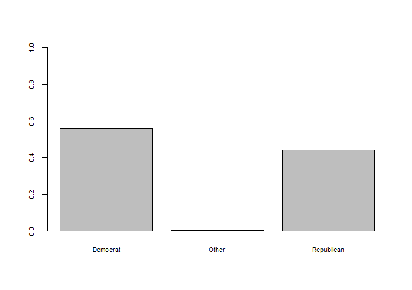

```r
barplot(prop.table(table(nominate_data$party)),
        names.arg = as.character(unique(nominate_data$party)),
        cex.names = 0.7,
        cex.axis = 0.7,
        ylim = c(0, 1)) # depict party shares
```

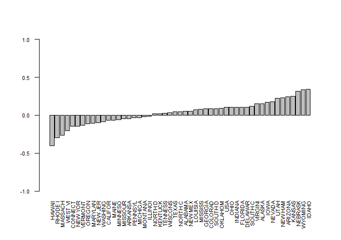

```r
nominate_states <- group_by(nominate_data, state) # group data by state
nominate_states <- summarise(nominate_states, n = n(), average_dw = mean(dwnom1)) # compute average dwnom score
nominate_states <- arrange(nominate_states, average_dw) # sort state grouped nominate data by average dwnom score
barplot(nominate_states$average_dw,
        names.arg = as.character(nominate_states$state),
        las=2,
        cex.names = 0.7,
        cex.axis = 0.7,
        ylim = c(-1, 1)) # depict average dwnom score by state (factor variable)
```

To visualize the distribution of a numeric variable, use `hist()` or `boxlplot()`.

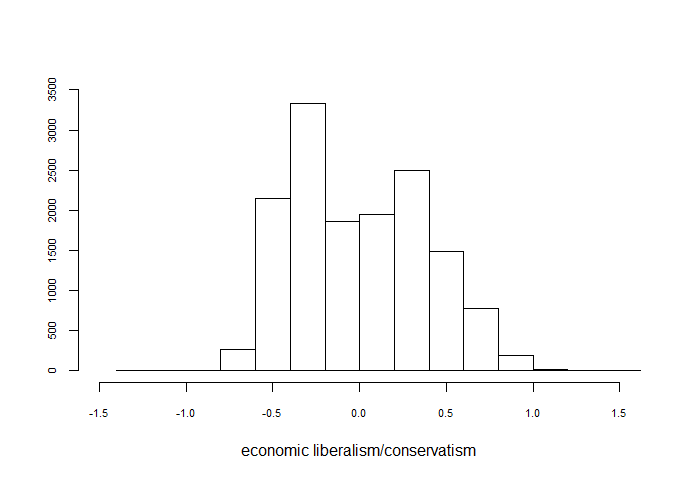

```r
hist(nominate_data$dwnom1,
     cex.axis = 0.7,
     xlim = c(-1.5, 1.5),
     ylim = c(0,3500),
     main = NULL,
     ylab = NULL,
     xlab = "economic liberalism/conservatism")
```

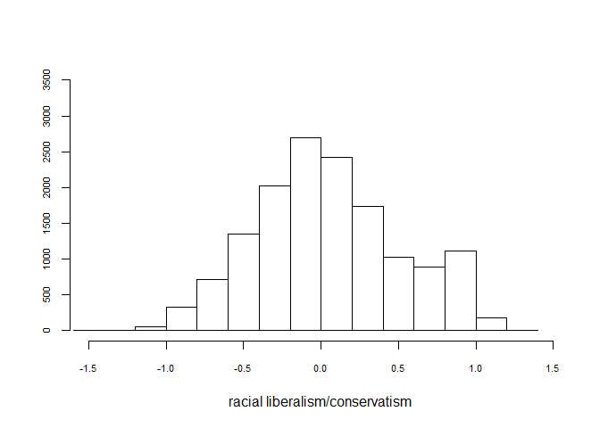

```r
hist(nominate_data$dwnom2,
     cex.axis = 0.7,
     xlim = c(-1.5, 1.5),
     ylim = c(0,3500),
     main = NULL,
     ylab = NULL,
     xlab = "racial liberalism/conservatism")
```

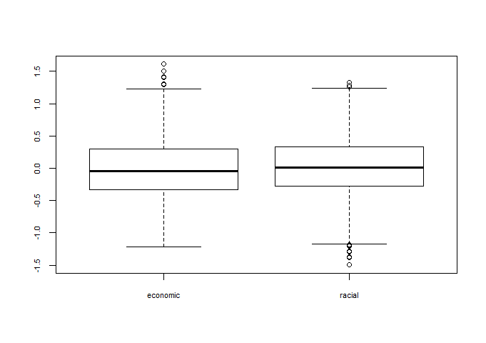

```r
boxplot(nominate_data$dwnom1,
        nominate_data$dwnom2,
        cex.axis = 0.7,
        names = c("economic", "racial"))
```

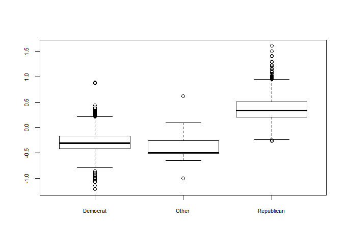

```r
boxplot(nominate_data$dwnom1 ~ nominate_data$party,
        cex.axis = 0.7)
```

To summarize bivariate relationships, use `plot`. Note that plot is a generic function, depending on the data input, the plot will look different and can do more than just scatterplots.

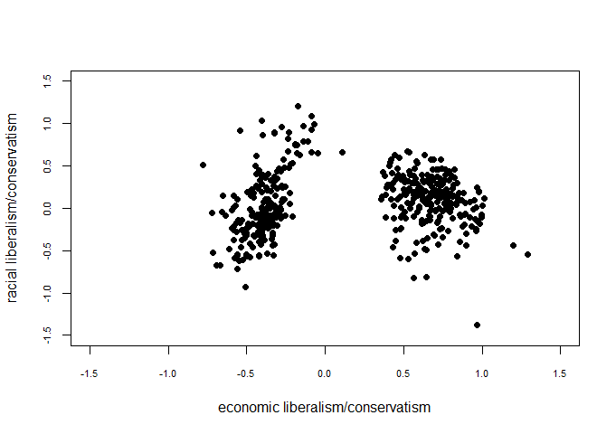

```r
plot(nominate_data[nominate_data$congress == 112, "dwnom1"],
     nominate_data[nominate_data$congress == 112, "dwnom2"],
     cex.axis = 0.7,
     xlim = c(-1.5, 1.5),
     ylim = c(-1.5, 1.5),
     xlab = "economic liberalism/conservatism",
     ylab = "racial liberalism/conservatism",
     pch = 16)
```

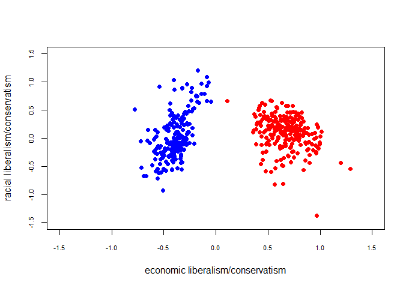

```r
plot(nominate_data[nominate_data$congress == 112, "dwnom1"],
     nominate_data[nominate_data$congress == 112, "dwnom2"],
     cex.axis = 0.7,
     xlim = c(-1.5, 1.5),
     ylim = c(-1.5, 1.5),
     xlab = "economic liberalism/conservatism",
     ylab = "racial liberalism/conservatism",
     pch = 16)
points(nominate_data[nominate_data$congress == 112 & nominate_data$party == "Republican", "dwnom1"],
       nominate_data[nominate_data$congress == 112 & nominate_data$party == "Republican", "dwnom2"],
       pch = 16,
       col = "red")
points(nominate_data[nominate_data$congress == 112 & nominate_data$party == "Democrat", "dwnom1"],
       nominate_data[nominate_data$congress == 112 & nominate_data$party == "Democrat", "dwnom2"],
       pch = 16,
       col = "blue")
```

##### Fitting regression models (frequentist style)?

To fit regression models in R, use `lm()` for linear models and `glm()` for generalized linear models. You might consider special R packages such as ‘MASS’, for instance for negative binomial models, ‘pscl’ for zero-inflated models, ‘clogit’ for discrete choice models, ‘zelig’ for a range of different models, and so on. Apart from some extras here and there, the notation is basically the same across all models, also hierarchical models. Type the outcome variable Y first, then use the tilde operator `~` to separate the left- and right-hand side of the equation, then type the deterministic part, i.e., the predictors. Note that the intercept is automatically added, to omit the intercept, write -1 after ~. To include interaction effects only, type `:` inbetween two variables you mean to interact. In order to also include the main effects, type `*` instead.

```r
nominate_data <- mutate(nominate_data, president = ifelse(state == "USA", TRUE, FALSE)) # variable identifying presidents
nominate_reg <- filter(nominate_data, congress == 112, party != "Other", president == FALSE)
levels(nominate_reg$party) <- c("Democrat", NA, "Republican")
linear_model <- lm(formula = dwnom1 ~ party, data = nominate_reg) # simple linear model with one covariate
summary(linear_model) # gives the difference in means of dwnom1 over subgroups (democrats and republicans)
```

```
#>
#> Call:
#> lm(formula = dwnom1 ~ party, data = nominate_reg)
#>
#> Residuals:
#>      Min       1Q   Median       3Q      Max
#> -0.56833 -0.10408 -0.00370  0.09014  0.61767
#>
#> Coefficients:
#>                 Estimate Std. Error t value Pr(>|t|)
#> (Intercept)     -0.39430    0.01089   -36.2   <2e-16 ***
#> partyRepublican  1.06963    0.01469    72.8   <2e-16 ***
#> ---
#> Signif. codes:  0 '***' 0.001 '**' 0.01 '*' 0.05 '.' 0.1 ' ' 1
#>
#> Residual standard error: 0.1537 on 440 degrees of freedom
#> Multiple R-squared:  0.9233, Adjusted R-squared:  0.9232
#> F-statistic:  5300 on 1 and 440 DF,  p-value: < 2.2e-16
```

## 6. Further topics and ressources

##### Where to go next

- improving code readability with the pipe operator (‘magrittr’ package)
- improving coding and documentation practice with R Markdown
- managing your file system
- working with relational data and databases
- working with strings and dates
- building functions
- mastering graphics
- discovering textual, spatial, and network data
- discovering distributions and statistical models
- automating Web data extraction
- optimizing your code via vectorization and data.table
- learning about packages that make it easier to work with R

##### Where to look

Books

- Gelman, Andrew and Jennifer Hill. 2007. Data analysis using regression and multilevel/hierarchical models. Cambridge: Cambridge University Press.
- Imai, Kosuke. 2017. Quantitative social science. An introduction. Princeton, NJ: Princeton University Press.
- Munzert, Simon, Christian Rubba, Peter Meißner, Dominic Nyhuis. 2015. Automated data collection with R. A practical guide to Web scraping and text mining. Chichester: Wiley.
- Wickham, Hadley. 2014. Advanced R. Boca Raton: CRC Press.
- Wickham, Hadley. 2009. Ggplot2. Elegant graphics for data analysis. New York: Springer
- Wickham, Hadley and Garrett Grolemund. R for data science. Sebastopol, CA: O’Reilly.

Online ressources

- https://stackoverflow.com/
- https://www.r-bloggers.com/
- https://cran.r-project.org/web/views/
- https://journal.r-project.org/
- https://www.rstudio.com/resources/cheatsheets/
- http://style.tidyverse.org/
- http://www.noamross.net/blog/2014/4/16/vectorization-in-r--why.html
- http://www.burns-stat.com/pages/Tutor/R_inferno.pdf

Recommended packages

- stringr - provides common string operations
- pacman - manage package installation and sourcing
- plyr - split-apply-combine paradigm
- dplyr - successor of plyr, tailored for data frames
- data.table - enhanced (fast and memory efficient) data.frame
- haven - import and export ‘SPSS’, ‘Stata’ and ‘SAS’ Files
- magrittr - provides the pipe operator
- ggplot2 - data visualization using the grammar of graphics, base R graphics can do just fine, though
- survey - analysis of complex survey samples
- writexl - read, write, and edit XLSX Files
- lubridate - dealing with dates
- zoo - dealing with time series
- eeptools - misc convenience functions
- httr - tools for working with URLs and HTTP
- rvest - tools for Web scraping
- XML - tools for parsing and generating XML
- crayon - colored terminal output